# Regression Analysis Final Project

Rakshit Chandna

2023-06-02

## *Introduction*

Life expectancy is one of the most used measures of overall health of a population. It is expressed as either the number of years of a newborn baby is expected to live, or the expected years of life remaining for a person at a given age and is estimated from the death rates in a population. Life expectancy is a measure that is often used to gauge the overall health of a community. Life expectancy at birth measures health status across all age groups. Shifts in life expectancy are often used to describe trends in mortality. It was found that the effect of immunization and human development index was not considered in the past. Hence, considering the data of life expectancy for the year 2014 for all the countries.

This project will focus on various factors such as immunization, mortality, economic, social and other health related factors as well. These factors in corresponding to the countries observations will help us analyze the life expectancy rates globally. The predicting variables can be divided into several broad categories: Immunization related factors, Mortality factors, Economical factors, and social factors.

### Dataset source

The data in the project has been used from Kaggle.com datasets which has been provided below. https://www.kaggle.com/datasets/kumarajarshi/life-expectancy-who?resource=download

## Descriptive features of the dataset:

The dataset has 2939 observations and 22 columns, and since the given dataset is a big one, we will only consider the below mentioned variables for our analysis.

- **Country**: The name of the country which is being analyzed
- **Life expectancy**: The average life expectancy of an average citizen from the country in question
- **Alcohol**: The average alcohol consumption by an average citizen in liters per year
- **Polio**: Percentage of Polio immunization coverage among 1-year-olds
- **Percentage expenditure**: General government expenditure on health as a percentage of total government expenditure
- **BMI**: Average Body Mass Index of entire population
- **GDP**: Gross Domestic Product per capita (in USD)
- **Schooling**: Number of years of Schooling(years)

### Necessary Libraries

```r
library(readr)
library(stats)
library(dplyr)
library(tidyr)
library(car)
library(stats)
library(GGally)
```

## Importing the Dataset

```r
LED <- read.csv("LED.csv")
head(LED)
```

```
##       Country Year     Status Life.expectancy Adult.Mortality infant.deaths
## 1 Afghanistan 2015 Developing            65.0             263            62
## 2 Afghanistan 2014 Developing            59.9             271            64
## 3 Afghanistan 2013 Developing            59.9             268            66
## 4 Afghanistan 2012 Developing            59.5             272            69
## 5 Afghanistan 2011 Developing            59.2             275            71
## 6 Afghanistan 2010 Developing            58.8             279            74
##   Alcohol percentage.expenditure Hepatitis.B Measles  BMI under.five.deaths
## 1    0.01              71.279624          65    1154 19.1                83
## 2    0.01              73.523582          62     492 18.6                86
## 3    0.01              73.219243          64     430 18.1                89
## 4    0.01              78.184215          67    2787 17.6                93
## 5    0.01               7.097109          68    3013 17.2                97
## 6    0.01              79.679367          66    1989 16.7               102
##   Polio Total.expenditure Diphtheria HIV.AIDS       GDP Population
```

[output cut: 20 more lines]

- Here we have imported the data set. We will now perform some data processing to work and prepare the data so we can work towards the aim.

### Data pre-processing

```r
dfled <- data.frame(LED)

LL <- dfled[dfled$Year == 2014,]
```

- Here we have converted the data set into a data frame and have subsetted the data set to the year of 2014, as we will be performing the analysis of the data from 2014.

### Changing Column names

```r
FLED <- subset(LL,, select = c("Country","Life.expectancy","Alcohol","Polio","percentage.expenditure","BMI","GDP","Schooling"))
colnames(FLED)[c(2:8)] <- c("Y","X1","X2","X3","X4","X5","X6")
head(FLED)
```

```
##                Country    Y   X1 X2         X3   X4         X5   X6
## 2          Afghanistan 59.9 0.01 58   73.52358 18.6   612.6965 10.0
## 18             Albania 77.5 4.51 98  428.74907 57.2  4575.7638 14.2
## 34             Algeria 75.4 0.01 95   54.23732 58.4   547.8517 14.4
## 50              Angola 51.7 8.33 68   23.96561 22.7   479.3122 11.4
## 66 Antigua and Barbuda 76.2 8.56 96 2422.99977 47.0 12888.2967 13.9
## 82           Argentina 76.2 7.93 92  847.37175 62.2 12245.2565 17.3
```

- As we will be focusing on specific varaiables, we have subsetted the data set to meet those certain requirements.
- We have also, changed the names of the data set for the ease of calculations. Y- Life.expectancy., X1= Alcohol, X2 = Polio, X3 = percentage.expenditure, X4 = BMI, X5= GDP, X6 = Schooling.

### Imputing “NA” values with “median”

```r
FLED<- FLED %>% mutate(across(X1, ~replace_na(., median(., na.rm=TRUE))))
which(is.na(FLED$X1))
```

```
## integer(0)
```

```r
which(is.na(FLED$X2))
```

```
## integer(0)
```

```r
which(is.na(FLED$X3))
```

```
## integer(0)
```

```r
which(is.na(FLED$X4))
```

```
## [1] 151 154
```

```r
FLED<- FLED %>% mutate(across(X4, ~replace_na(., median(., na.rm=TRUE))))
which(is.na(FLED$X4))
```

```
## integer(0)
```

```r
which(is.na(FLED$X5))
```

```
##  [1]  11  20  28  39  44  45  46  51  54  61  77  89  90  95 107 131 132 136 137
## [20] 146 159 162 173 174 175 179 180 181
```

```r
FLED<- FLED %>% mutate(across(X5, ~replace_na(., median(., na.rm=TRUE))))
which(is.na(FLED$X5))
```

```
## integer(0)
```

```r
which(is.na(FLED$X6))
```

```
##  [1]  28  44  45  46 131 132 149 173 174 175
```

```r
FLED<- FLED %>% mutate(across(X6, ~replace_na(., median(., na.rm=TRUE))))
which(is.na(FLED$X6))
```

```
## integer(0)
```

- The data frame had certain NA values. Which we have replaced with their median values.
- We found that the predictors X1, X4, X5, X6 had missing values and we imputed them with their respective median values.

### Variables correlation

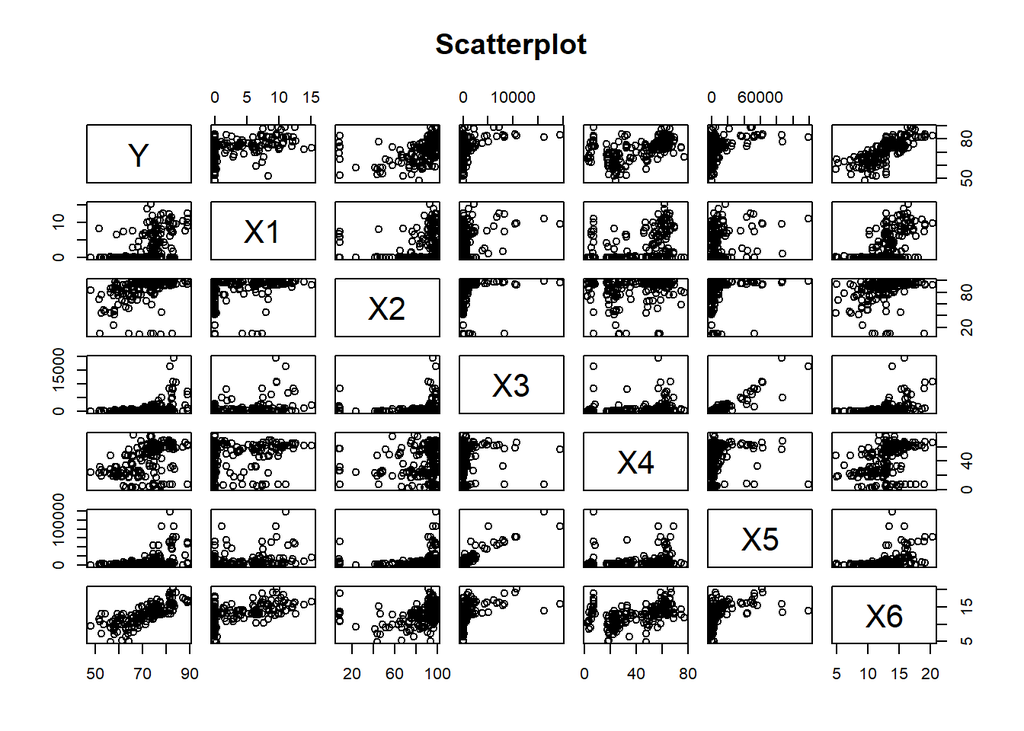

```r
plot(~Y+X1+X2+X3+X4+X5+X6,data=FLED,main="Scatterplot")
```

```r
cor(FLED$Y,FLED$X1)
```

```
## [1] 0.5255795
```

```r
cor(FLED$Y,FLED$X2)
```

```
## [1] 0.4072733
```

```r
cor(FLED$Y,FLED$X3)
```

```
## [1] 0.3988396
```

```r
cor(FLED$Y,FLED$X4)
```

```
## [1] 0.4716515
```

```r
cor(FLED$Y,FLED$X5)
```

```
## [1] 0.435996
```

```r
cor(FLED$Y,FLED$X6)
```

```
## [1] 0.7722707
```

- We plot the scatterplot for the variables.
- We also find the correlation values and found that X6 has a very strong correlation of 0.7722 with dependent variable Y.

### Basic Multiple Linear Regression Model

```r
model<-lm(Y~X1+X2+X3+X4+X5+X6,FLED)
summary(model)
```

```
##
## Call:
## lm(formula = Y ~ X1 + X2 + X3 + X4 + X5 + X6, data = FLED)
##
## Residuals:
##      Min       1Q   Median       3Q      Max
## -16.4988  -2.7049   0.5238   3.1538  11.0389
##
## Coefficients:
##              Estimate Std. Error t value Pr(>|t|)
## (Intercept) 4.044e+01  2.227e+00  18.155  < 2e-16 ***
## X1          1.954e-01  1.138e-01   1.718 0.087583 .
## X2          7.225e-02  1.898e-02   3.807 0.000194 ***
## X3          8.467e-05  3.676e-04   0.230 0.818113
## X4          5.682e-02  2.036e-02   2.791 0.005838 **
## X5          4.946e-05  5.445e-05   0.908 0.364955
## X6          1.666e+00  1.785e-01   9.329  < 2e-16 ***
## ---
## Signif. codes:  0 '***' 0.001 '**' 0.01 '*' 0.05 '.' 0.1 ' ' 1
##
## Residual standard error: 5.032 on 176 degrees of freedom
## Multiple R-squared:  0.6659, Adjusted R-squared:  0.6545
## F-statistic: 58.47 on 6 and 176 DF,  p-value: < 2.2e-16
```

Model Equation: $\hat {Y}= (4.044e+01) + (1.954e-01) \hspace{0.1 cm} X1 + (7.225e-02) \hspace{0.1 cm} X2 + (8.467e-05) \hspace{0.1 cm} X3 + (5.682e-02) \hspace{0.1 cm} X4 + (4.946e-05) \hspace{0.1 cm} X5 + (1.666e+00) \hspace{0.1 cm} X6$

### Residual Analysis

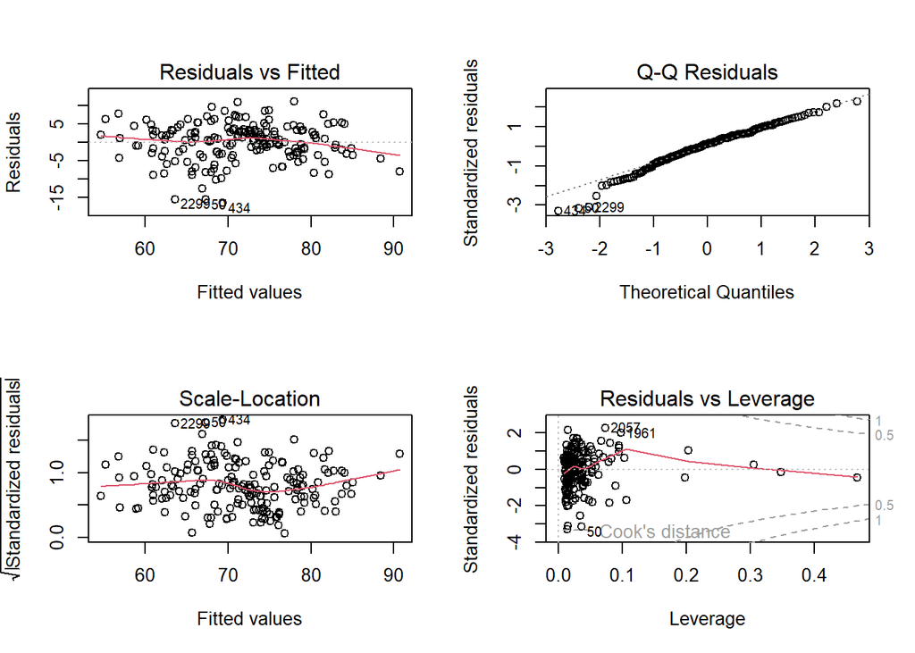

```r
par(mfrow=c(2,2))
plot(model)
```

- Concluding whether any assumptions have been violated or not just by the plots is difficult hence we will conduct certain test for evidence.

### *1 Non-constant error variance test*

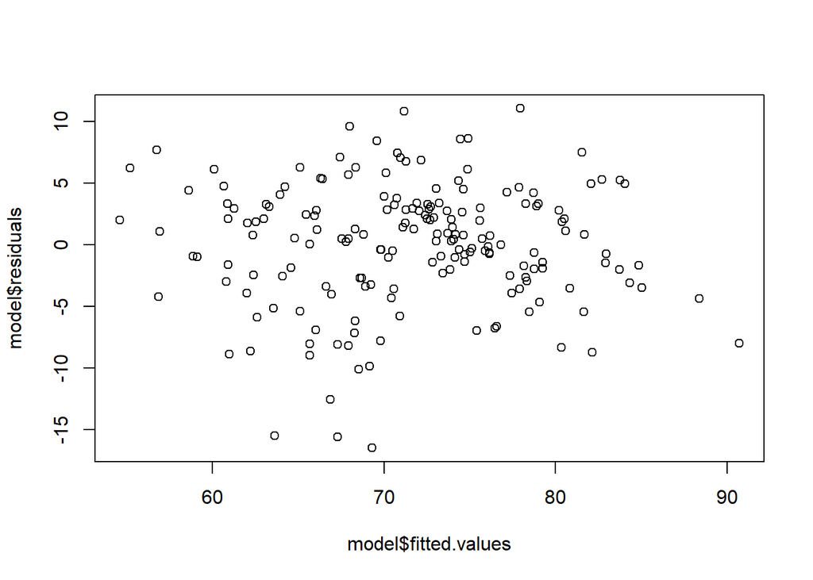

```r
plot(model$fitted.values, model$residuals)
```

```r
ncvTest(model)
```

```
## Non-constant Variance Score Test
## Variance formula: ~ fitted.values
## Chisquare = 3.02994, Df = 1, p = 0.081741
```

- Here,H0: Errors have constant variance and HA: Errors have a non-constant variance
- The p value = 0.081741, which is greater than 0.05 so we fail to reject the H0 and can say we have enough evidence to say that the constant error variance assumption is not violated.

### *2 Test for Normally Distributed Errors*

```r
shapiro.test(model$residuals)
```

```
##
##  Shapiro-Wilk normality test
##
## data:  model$residuals
## W = 0.97488, p-value = 0.002191
```

### *3 Test for Autocorrelated Errors*

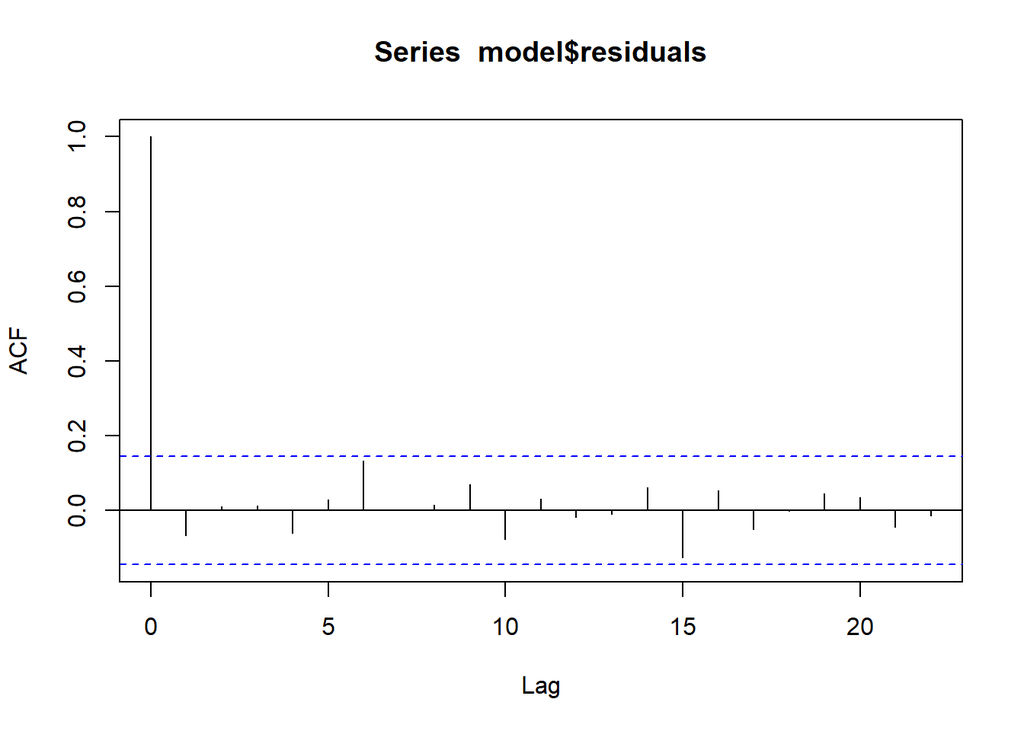

```r
acf(model$residuals)
```

```r
durbinWatsonTest(model)
```

```
##  lag Autocorrelation D-W Statistic p-value
##    1     -0.06691558       2.11773   0.384
##  Alternative hypothesis: rho != 0
```

### *4 Test for Linearity*

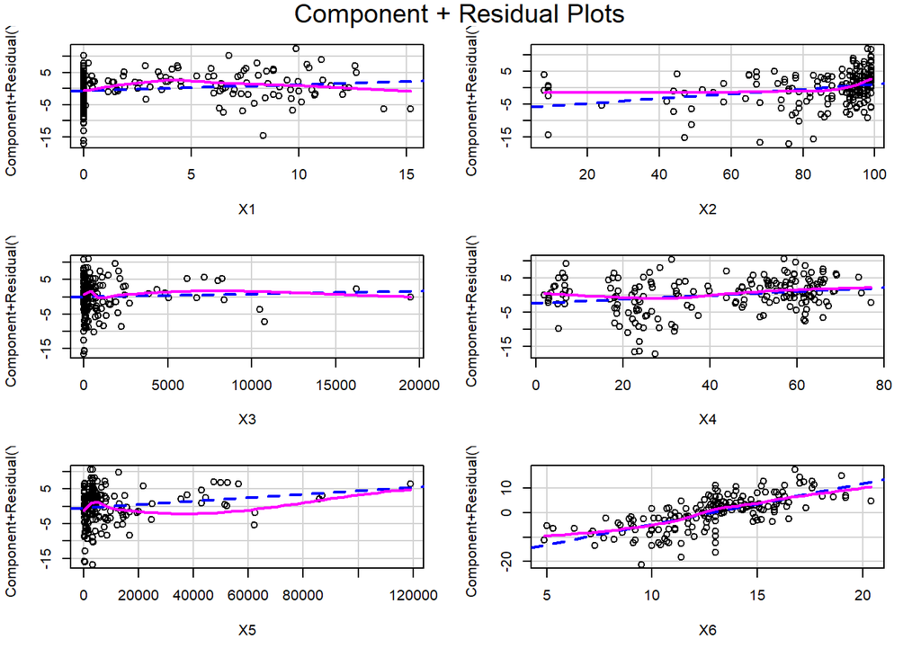

```r
crPlots(model)
```

- One of the key assumptions of multiple linear regression is that there exists a linear relationship between each predictor variable and the response variable.If this assumption is violated, then the results of the regression model can be unreliable. We will check this assumption by creating a partial residual plot, which displays the residuals of one predictor variable against the response variable.
- The blue line shows the expected residuals if the relationship between the predictor and response variable was linear. The pink line shows the actual residuals.If the two lines are significantly different, then this is evidence of a nonlinear relationship.The predictor variables X1,X2 and X5 are fairly non-linear.

```r
head(FLED)
```

```
##                Country    Y   X1 X2         X3   X4         X5   X6
## 2          Afghanistan 59.9 0.01 58   73.52358 18.6   612.6965 10.0
## 18             Albania 77.5 4.51 98  428.74907 57.2  4575.7638 14.2
## 34             Algeria 75.4 0.01 95   54.23732 58.4   547.8517 14.4
## 50              Angola 51.7 8.33 68   23.96561 22.7   479.3122 11.4
## 66 Antigua and Barbuda 76.2 8.56 96 2422.99977 47.0 12888.2967 13.9
## 82           Argentina 76.2 7.93 92  847.37175 62.2 12245.2565 17.3
```

### *5 Test for Multi-collinearity*

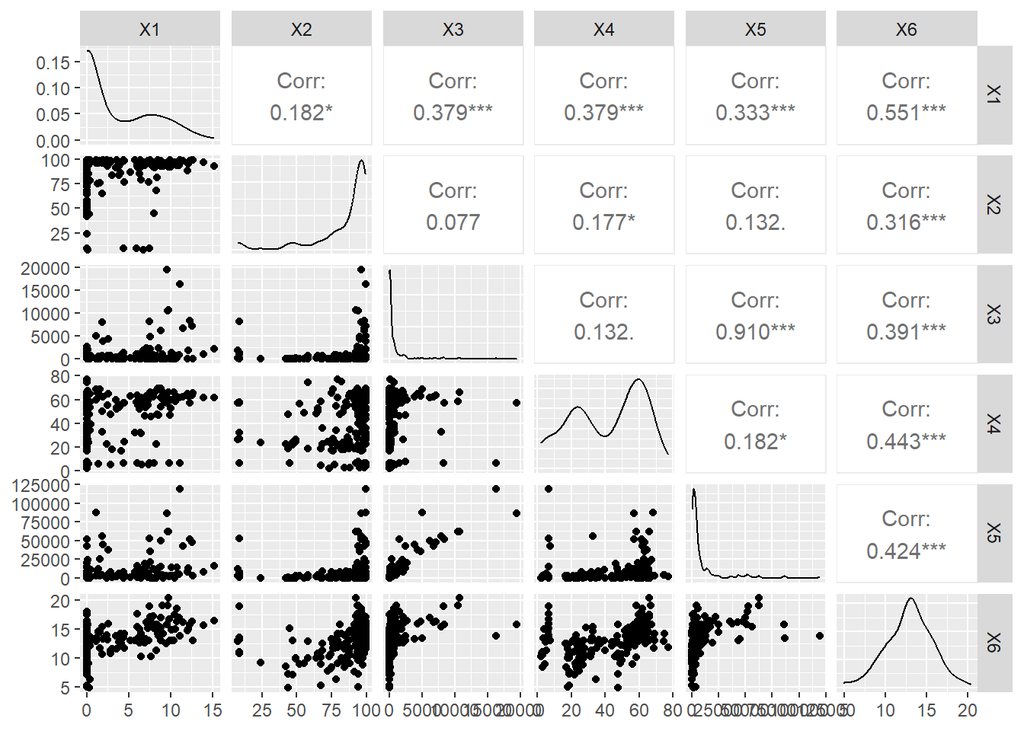

```r
ggpairs(data = FLED, columns = c(3:8))
```

* From the matrix we can see that there exists strong correlation between the independent variables. This is an indication of multi-collinearity and hence the multi- collinearity assumption has been violated.

```r
vif(model)
```

```
##       X1       X2       X3       X4       X5       X6
## 1.601550 1.127474 6.333159 1.314451 6.291358 1.835731
```

## Model Transformation

- We will now perform few transformation on our basic model to select the best model possible. The types of transformations would be:

## Log Traansformation

```r
modellog<-lm(log(Y)~X1+X2+X3+X4+X5+X6,FLED)
summary(modellog)
```

```
##
## Call:
## lm(formula = log(Y) ~ X1 + X2 + X3 + X4 + X5 + X6, data = FLED)
##
## Residuals:
##      Min       1Q   Median       3Q      Max
## -0.27676 -0.03769  0.01210  0.04871  0.14696
##
## Coefficients:
##              Estimate Std. Error t value Pr(>|t|)
## (Intercept) 3.810e+00  3.333e-02 114.307  < 2e-16 ***
## X1          2.516e-03  1.702e-03   1.478 0.141259
## X2          1.126e-03  2.840e-04   3.966 0.000106 ***
## X3          3.987e-07  5.501e-06   0.072 0.942301
## X4          8.758e-04  3.047e-04   2.875 0.004544 **
## X5          7.336e-07  8.148e-07   0.900 0.369140
## X6          2.372e-02  2.672e-03   8.880 7.59e-16 ***
## ---
## Signif. codes:  0 '***' 0.001 '**' 0.01 '*' 0.05 '.' 0.1 ' ' 1
##
## Residual standard error: 0.0753 on 176 degrees of freedom
## Multiple R-squared:  0.6455, Adjusted R-squared:  0.6334
## F-statistic: 53.41 on 6 and 176 DF,  p-value: < 2.2e-16
```

Model Equation: $\hat {Y}= (3.810e+00) + (2.516e-03) \hspace{0.1 cm} X1 + (1.126e-03) \hspace{0.1 cm} X2 + (3.987e-07) \hspace{0.1 cm} X3 + (8.758e-04) \hspace{0.1 cm} X4 + (7.336e-07) \hspace{0.1 cm} X5 + (2.372e-02) \hspace{0.1 cm} X6$

- WE performed a log transformation to check if there is any improvement in the model.
- We can see that the R-Squared value is 0.6455,meaning 64.55% of the variability in the data is explained by the model, the adjusted R-Squared value is 0.6334. Only the predictors X2,X4 and X6 are significant.

### *Residual Analysis*

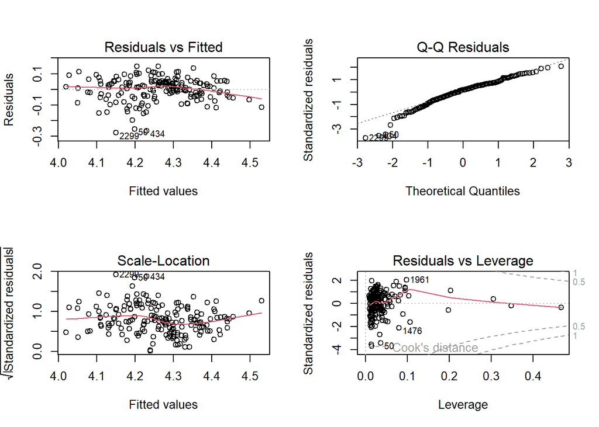

```r
par(mfrow=c(2,2))
plot(modellog)
```

### *1 Non-constant error variance test*

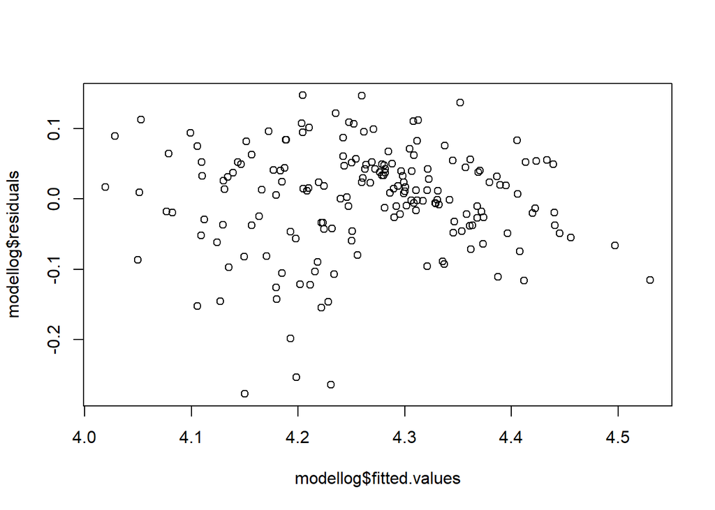

```r
plot(modellog$fitted.values, modellog$residuals)
```

```r
ncvTest(modellog)
```

```
## Non-constant Variance Score Test
## Variance formula: ~ fitted.values
## Chisquare = 10.11096, Df = 1, p = 0.0014739
```

- Here, $H0$: Errors have constant variance and $HA$: Errors have a non-constant variance.
- we can observe the P value = 0.0014739, which is less than $0.05$ hence we reject the null hypothesis. This indicates that the constant error variance assumption is violated.

### *2 Test for Normally Distributed Errors*

```r
shapiro.test(modellog$residuals)
```

```
##
##  Shapiro-Wilk normality test
##
## data:  modellog$residuals
## W = 0.95248, p-value = 8.188e-06
```

- Here, $H0$: Errors are normally distributed and $HA$: Errors are not normally distributed.
- Here, p value can be observed is less than $0.05$, hence we have enough evidence to reject the $H0$. This indicates that the normality error assumption is violated.

### *3 Test for Autocorrelated Errors*

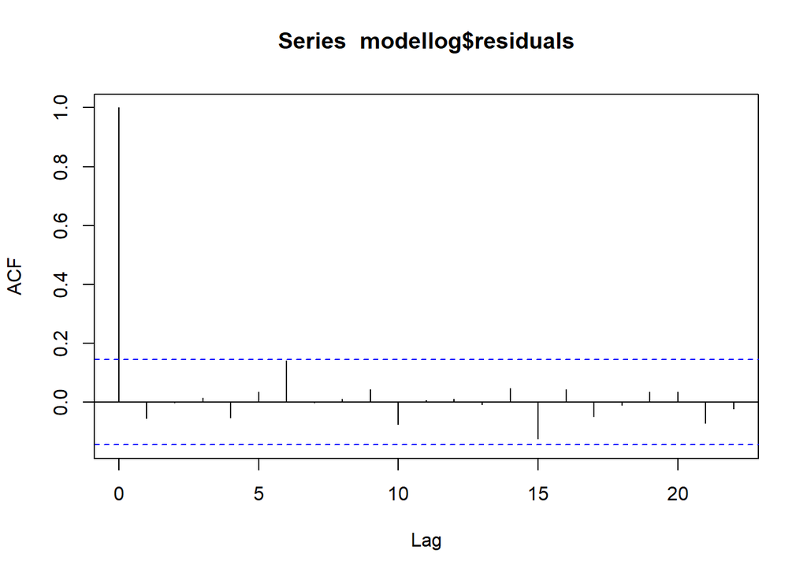

```r
acf(modellog$residuals)
```

```r
durbinWatsonTest(modellog)
```

```
##  lag Autocorrelation D-W Statistic p-value
##    1     -0.05434535      2.092611   0.542
##  Alternative hypothesis: rho != 0
```

- Here, $H0$: Errors are uncorrelated and $HA$: Errors are correlated.
- The P value is greater than 0.05, hence we do not have enough evidence to reject the $H0$, this indicates that the uncorrelated error assumption is not violated.

### *4 Test for Linearity*

One of the key assumptions of multiple linear regression is that there exists a linear relationship between each predictor variable and the response variable.If this assumption is violated, then the results of the regression model can be unreliable. We will check this assumption by creating a partial residual plot, which displays the residuals of one predictor variable against the response variable.

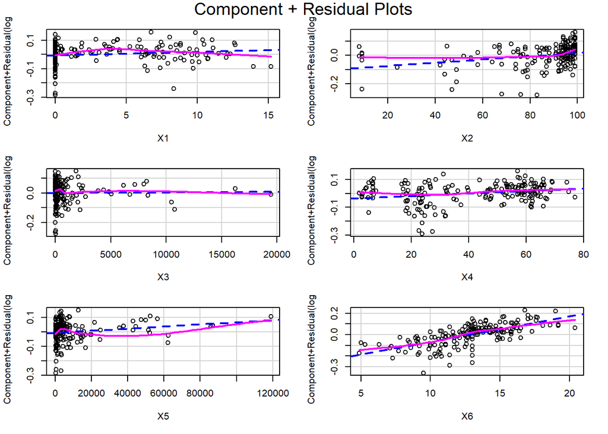

```r
crPlots(modellog)
```

- The blue line shows the expected residuals if the relationship between the predictor and response variable was linear. The pink line shows the actual residuals.If the two lines are significantly different, then this is evidence of a nonlinear relationship.The predictor variables X1,X2 and X5 are fairly non-linear.

## Square Root Transformation

```r
modelsqrt <- lm(sqrt(Y)~X1+X2+X3+X4+X5+X6,FLED)

summary(modelsqrt)
```

```
##
## Call:
## lm(formula = sqrt(Y) ~ X1 + X2 + X3 + X4 + X5 + X6, data = FLED)
##
## Residuals:
##      Min       1Q   Median       3Q      Max
## -1.04215 -0.15700  0.04399  0.19390  0.62988
##
## Coefficients:
##              Estimate Std. Error t value Pr(>|t|)
## (Intercept) 6.569e+00  1.357e-01  48.398  < 2e-16 ***
## X1          1.108e-02  6.932e-03   1.599  0.11164
## X2          4.504e-03  1.156e-03   3.894  0.00014 ***
## X3          3.320e-06  2.240e-05   0.148  0.88237
## X4          3.526e-03  1.241e-03   2.842  0.00502 **
## X5          3.012e-06  3.318e-06   0.908  0.36527
## X6          9.927e-02  1.088e-02   9.124  < 2e-16 ***
## ---
## Signif. codes:  0 '***' 0.001 '**' 0.01 '*' 0.05 '.' 0.1 ' ' 1
##
## Residual standard error: 0.3066 on 176 degrees of freedom
## Multiple R-squared:  0.6567, Adjusted R-squared:  0.645
## F-statistic: 56.12 on 6 and 176 DF,  p-value: < 2.2e-16
```

Model Equation: $\hat {Y}= (6.569e+00) + (1.108e-02) \hspace{0.1 cm} X1 + (4.504e-03) \hspace{0.1 cm} X2 + (3.320e-06) \hspace{0.1 cm} X3 + (3.526e-03) \hspace{0.1 cm} X4 + (3.012e-06) \hspace{0.1 cm} X5 + (9.927e-02) \hspace{0.1 cm} X6$

- WE performed a Square Root transformation to check if there is any improvement in the model.
- We can see that the R-Squared value is 0.6567,meaning 65.7% of the variability in the data is explained by the model, the adjusted R-Squared value is 0.645. Only the predictors X2,X4 and X6 are significant.

### Residual Analysis

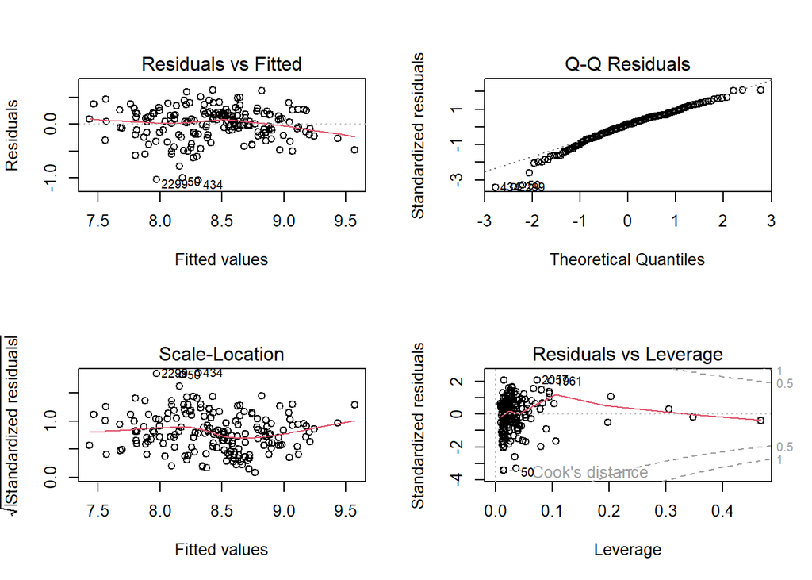

```r
par(mfrow=c(2,2))
plot(modelsqrt)
```